# 08-09-assignment_chen

Evelyn Chen

10/19/2019

```r
library(tidyverse)
library(knitr)
library(modelr)
library(caret)
library(forcats)
library(ModelMetrics)
```

I went to the kaggle website, as directed, and I downloaded the data files associated with the “Don’t get Kicked” competition. The competition is to predict if a car purchased at the Auction is a Kick - a bad buy. We will be using statistics to figure out which cars have a higher risk of being a kick, in an attempt to provide the best inventory selection possible to the customers of an auto dealership.

The datasets were downloaded from the kaggle website, copied and pasted into my working directory, and then renamed. The following code will upload the datasets.

```r
#clear environment
rm(list=ls())
#load the datasets
training<-read_csv(file="08-09-assignment_training.csv")
test<-read_csv(file="08-09-assignment_test.csv")
```

### 1 - Calculate the proportion of lemons in the training dataset using the IsBadBuy variable.

The dependent variable, ‘IsBadBuy’ denotes whether or not the car purchased was a lemon - a purchase that could have been avoided, The first command, table(), will tell us the raw number, and the second command, ‘prop.table’ will show us the proportion of cars identified as bad buys.

```r
table(training$IsBadBuy)
```

```
##
##     0     1
## 64007  8976
```

```r
prop.table(table(training$IsBadBuy))
```

```
##
##         0         1
## 0.8770125 0.1229875
```

In the training dataset, 64007 cars were not kicked, and 8976 cars were considered “lemons” - kicked vehicles. The output shows that 12.3% of the total cars purchased were considered lemons.

### 2 - Calculate the proportions of lemon by Make.

To determine the proportion of lemon by the make of a car, we use the ‘prop.table’ command to change the raw counts to proportions.

```r
prop.table(table(training$Make,training$IsBadBuy),margin=1)
```

```
##
##                         0          1
##   ACURA        0.72727273 0.27272727
##   BUICK        0.84305556 0.15694444
##   CADILLAC     0.84848485 0.15151515
##   CHEVROLET    0.90253942 0.09746058
##   CHRYSLER     0.87143826 0.12856174
##   DODGE        0.89676270 0.10323730
##   FORD         0.84590889 0.15409111
##   GMC          0.88443760 0.11556240
##   HONDA        0.89134809 0.10865191
##   HUMMER       1.00000000 0.00000000
##   HYUNDAI      0.87134180 0.12865820
##   INFINITI     0.66666667 0.33333333
##   ISUZU        0.93283582 0.06716418
##   JEEP         0.84549878 0.15450122
##   KIA          0.88244767 0.11755233
##   LEXUS        0.64516129 0.35483871
##   LINCOLN      0.70103093 0.29896907
##   MAZDA        0.83861083 0.16138917
##   MERCURY      0.83023001 0.16976999
##   MINI         0.66666667 0.33333333
##   MITSUBISHI   0.88058252 0.11941748
##   NISSAN       0.84028777 0.15971223
##   OLDSMOBILE   0.79835391 0.20164609
##   PLYMOUTH     0.50000000 0.50000000
##   PONTIAC      0.88093001 0.11906999
##   SATURN       0.85852982 0.14147018
##   SCION        0.91472868 0.08527132
##   SUBARU       0.78571429 0.21428571
##   SUZUKI       0.85316265 0.14683735
##   TOYOTA       0.90034965 0.09965035
##   TOYOTA SCION 1.00000000 0.00000000
##   VOLKSWAGEN   0.85820896 0.14179104
##   VOLVO        1.00000000 0.00000000
```

There were 33 makes of cars in the entire dataset. When sorted based on this characteristic, none of the Hummer, Volvo, Toyoto Scion cars were lemons. Plymouth had one the highest proportions of lemons in the dataset, 0.50. Lexus, Infiniti, and Lincoln also had fairly high proportions of lemons, 0.35, 0.33, and 0.30, respectively.

### 3 - Now, predict the probability of being a lemon using a linear model (lm(y~x)), with covariates of your choosing from the training dataset.

I am curious to understand the extent to which the vehicle’s age predicts the probability of a car being a lemon.

```r
summary(training$VehicleAge)
```

```
##    Min. 1st Qu.  Median    Mean 3rd Qu.    Max.
##   0.000   3.000   4.000   4.177   5.000   9.000
```

The variable, ‘VehicleAge’ is described as the years elapsed since the manufacturer’s year. When I executed the summary command, the cars in this dataset range from 0 - 9 years, with an average of 4.177.

```r
prop.table(table(training$VehicleAge,training$IsBadBuy),margin=1)
```

```
##
##              0          1
##   0 1.00000000 0.00000000
##   1 0.95959922 0.04040078
##   2 0.93633577 0.06366423
##   3 0.91818639 0.08181361
##   4 0.89043672 0.10956328
##   5 0.85373572 0.14626428
##   6 0.81962104 0.18037896
##   7 0.78368489 0.21631511
##   8 0.73108108 0.26891892
##   9 0.68730650 0.31269350
```

It appears that there is a position association between vehicle age and proportion of cars that are kicked back. None of the brand-new cars (vehicleage=0) were kicked back. One-, two-, three-year old cars show an incrementally higher proportion of lemons, and the proportion continues to increase up to the oldest cars in the dataset, 9 years. The following command runs a linear regression model of lemons as a function of vehicle age, using the training dataset.

```r
#linear model of lemons as a function of vehicle age, data set=training
mod1<-lm(IsBadBuy~VehicleAge,data=training) #outcome on left, predictor on right

summary(mod1)
```

```
##
## Call:
## lm(formula = IsBadBuy ~ VehicleAge, data = training)
##
## Residuals:
##      Min       1Q   Median       3Q      Max
## -0.27765 -0.14939 -0.11732 -0.05319  0.97887
##
## Coefficients:
##             Estimate Std. Error t value Pr(>|t|)
## (Intercept) -0.01093    0.00316   -3.46  0.00054 ***
## VehicleAge   0.03206    0.00070   45.80  < 2e-16 ***
## ---
## Signif. codes:  0 '***' 0.001 '**' 0.01 '*' 0.05 '.' 0.1 ' ' 1
##
## Residual standard error: 0.3238 on 72981 degrees of freedom
## Multiple R-squared:  0.02794,    Adjusted R-squared:  0.02793
## F-statistic:  2098 on 1 and 72981 DF,  p-value: < 2.2e-16
```

### 4 - Make predictions from the linear model.

The relationship between vehicle age and car kick-back is statistically significant (p<0.001). We can reject the null hypothesis that the coefficient is zero. The coefficient of ‘vehicleage’ is 0.03, which suggests that for every additional year in the age of a vehicle, the proportion/likelihood of a car being a lemon increases by .03. The residual standard error, the RMSE, is 0.3238. This suggests that on average, our linear regression model is off by 0.3238.

### 5 - Now, predict the probability of being a lemon using a logistic regression (glm(y~x,family=binomial(link=“logit”))), again using covariates of your choosing.

Logistic regression is set up to handle binary outcomes as the dependent variable. It follows that the logistic regression is appropriate to use, because our chosen dependent variable, IsBadBuy, reveals a binary outcome. We will use the command ‘glm(y~x,family=binomal(link=“logit”))’ to run this logistic regression model.

```r
logit_mod<-glm(IsBadBuy~
            VehicleAge,
             data=training,
            na.action=na.exclude,
            family=binomial(link="logit"),
               y=TRUE)

summary(logit_mod)
```

```
##
## Call:
## glm(formula = IsBadBuy ~ VehicleAge, family = binomial(link = "logit"),
##     data = training, na.action = na.exclude, y = TRUE)
##
## Deviance Residuals:
##     Min       1Q   Median       3Q      Max
## -0.9081  -0.5482  -0.4793  -0.3643   2.4562
##
## Coefficients:
##              Estimate Std. Error z value Pr(>|z|)
## (Intercept) -3.252998   0.033156  -98.11   <2e-16 ***
## VehicleAge   0.286699   0.006477   44.26   <2e-16 ***
## ---
## Signif. codes:  0 '***' 0.001 '**' 0.01 '*' 0.05 '.' 0.1 ' ' 1
##
## (Dispersion parameter for binomial family taken to be 1)
##
##     Null deviance: 54421  on 72982  degrees of freedom
## Residual deviance: 52444  on 72981  degrees of freedom
## AIC: 52448
##
## Number of Fisher Scoring iterations: 5
```

The association between the covariate (VehicleAge) and outcome (IsBadBuy) is statistically significant, and the association is positive.

### 6 - Make predictions from the logit model. Make sure these are probabilities.

The logistic regression model demonstrates a statistically significant relationship between vehicle age and the outcome variable, ‘IsBadBuy’. It is likely that the age of the car is significantly correlated to the proportion of cars that are kicked-back.

With these results, we can generate predicted probabilities. To do this, we will use the ‘predict’ command, specifying to use the logistic regression model, ‘logit_mod’ and the type of response=“response” specifies that we want the predicted probabilities. The new predicted probabilities are labeled with a new variable, ‘pred_logit’.

```r
training<-training%>%
  mutate(pred_logit=predict(logit_mod,type="response"))

summary(training$pred_logit)
```

```
##    Min. 1st Qu.  Median    Mean 3rd Qu.    Max.
## 0.03722 0.08372 0.10850 0.12299 0.13949 0.33789
```

The summary command show that the predicted probabilities range from 0.037 to 0.338. In other words, the logistic model predicts that the predicted percentage of kickback cars range from 3.7% to 33.8%. The average predicted probability is 0.122 or 12.2%. None of the predicted probabilities are above 0.5 or 50%.

We can convert the predictions to a binary variable by setting a “threshold” of .3. Any prediction above .3 is considered to be a 1 (car is a bad buy), anything below, a 0 (car is not a bad buy).

```r
training<-training%>%
    mutate(pred_logit_out=ifelse(pred_logit>=.3,1,0))
```

```r
confusionMatrix<-confusionMatrix(training$pred_logit_out,training$IsBadBuy)
rownames(confusionMatrix)<-c("Predicted 0","Predicted 1")
colnames(confusionMatrix)<-c("Actual 0", "Actual 1")
confusionMatrix
```

```
##             Actual 0 Actual 1
## Predicted 0    63563      444
## Predicted 1     8774      202
```

It’s likely that if we changed the classification threshold, lowering it down further, our sensitivity and specificity of the model may improve.

### 8 - Plot the probability of a car being a bad buy by make.

I will use my logistic regression model from earlier (question #6), which examined the relationship between vehicle age and the outcome variable, ‘IsBadBuy’. We previously generated predicted probabilities, labeled it with a new variable ‘pred_logit.’

To plot the probability of a car being a bad buy by make, we will use ‘Make’ as the independent variable and ‘pred_logit’ as the dependent variable. The command ‘ggplot’ and ‘geom_bar’ will create a bar plot.

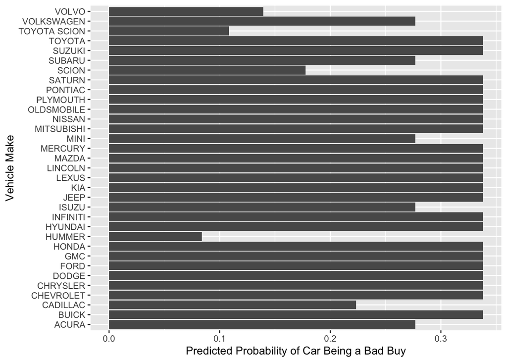

```r
gg<-ggplot(training,aes(x=Make,y=pred_logit))
gg<-gg+geom_bar(stat="identity", position="dodge")
gg<-gg+xlab("Vehicle Make")+ylab("Predicted Probability of Car Being a Bad Buy")
gg<-gg+coord_flip()
gg
```

I’m second-guessing my answer from above, because the predicted probabilities were based on examining the association between vehicle age and the outcome variable. The predicted probabilities were based on the logistic model I ran earlier in question #5 and #6. So, I decided to conduct a quick linear regression model of lemons as a function of the vehicle make. Then, I created a new variable of predicted probabilities (‘pred_lm_make’) based on this regression model. I feel as though the predicted probabilities better answer the question.

```r
#linear model of lemons as a function of car make, data set=training
mod2<-lm(IsBadBuy~Make,data=training) #outcome on left, predictor on right

summary(mod2)
```

```
##
## Call:
## lm(formula = IsBadBuy ~ Make, data = training)
##
## Residuals:
##      Min       1Q   Median       3Q      Max
## -0.50000 -0.14147 -0.10324 -0.09746  0.93284
##
## Coefficients:
##                  Estimate Std. Error t value Pr(>|t|)
## (Intercept)       0.27273    0.05700   4.785 1.72e-06 ***
## MakeBUICK        -0.11578    0.05829  -1.986 0.047011 *
## MakeCADILLAC     -0.12121    0.08061  -1.504 0.132675
## MakeCHEVROLET    -0.17527    0.05706  -3.072 0.002128 **
## MakeCHRYSLER     -0.14417    0.05711  -2.524 0.011590 *
## MakeDODGE        -0.16949    0.05707  -2.970 0.002982 **
## MakeFORD         -0.11864    0.05708  -2.078 0.037688 *
## MakeGMC          -0.15716    0.05843  -2.690 0.007153 **
## MakeHONDA        -0.16408    0.05886  -2.787 0.005315 **
## MakeHUMMER       -0.27273    0.33237  -0.821 0.411904
## MakeHYUNDAI      -0.14407    0.05752  -2.505 0.012256 *
## MakeINFINITI      0.06061    0.07617   0.796 0.426233
## MakeISUZU        -0.20556    0.06363  -3.230 0.001237 **
## MakeJEEP         -0.11823    0.05757  -2.054 0.040019 *
## MakeKIA          -0.15517    0.05738  -2.704 0.006844 **
## MakeLEXUS         0.08211    0.08190   1.003 0.316075
## MakeLINCOLN       0.02624    0.06599   0.398 0.690873
## MakeMAZDA        -0.11134    0.05795  -1.921 0.054716 .
## MakeMERCURY      -0.10296    0.05802  -1.774 0.075993 .
## MakeMINI          0.06061    0.08784   0.690 0.490244
## MakeMITSUBISHI   -0.15331    0.05791  -2.648 0.008110 **
## MakeNISSAN       -0.11302    0.05745  -1.967 0.049167 *
## MakeOLDSMOBILE   -0.07108    0.06075  -1.170 0.241968
## MakePLYMOUTH      0.22727    0.23845   0.953 0.340535
## MakePONTIAC      -0.15366    0.05722  -2.685 0.007248 **
## MakeSATURN       -0.13126    0.05743  -2.285 0.022295 *
## MakeSCION        -0.18746    0.06388  -2.935 0.003340 **
## MakeSUBARU       -0.05844    0.08413  -0.695 0.487290
## MakeSUZUKI       -0.12589    0.05770  -2.182 0.029141 *
## MakeTOYOTA       -0.17308    0.05782  -2.994 0.002759 **
## MakeTOYOTA SCION -0.27273    0.33237  -0.821 0.411904
## MakeVOLKSWAGEN   -0.13094    0.06363  -2.058 0.039628 *
## MakeVOLVO        -0.27273    0.07840  -3.479 0.000504 ***
## ---
## Signif. codes:  0 '***' 0.001 '**' 0.01 '*' 0.05 '.' 0.1 ' ' 1
##
## Residual standard error: 0.3274 on 72950 degrees of freedom
## Multiple R-squared:  0.006388,   Adjusted R-squared:  0.005952
## F-statistic: 14.66 on 32 and 72950 DF,  p-value: < 2.2e-16
```

```r
training<-training%>%
  mutate(pred_lm_make=predict(mod2,type="response"))

summary(training$pred_lm_make)
```

```
##    Min. 1st Qu.  Median    Mean 3rd Qu.    Max.
## 0.00000 0.09965 0.11907 0.12299 0.14684 0.50000
```

The commands below will plot the predicted probabilities as a bar plot.

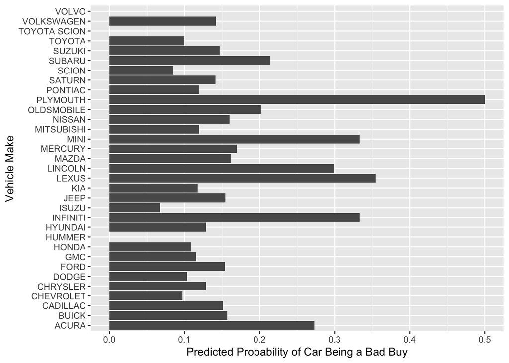

```r
gg<-ggplot(training,aes(x=Make,y=pred_lm_make))
gg<-gg+geom_bar(stat="identity",position="dodge")
gg<-gg+xlab("Vehicle Make")+ylab("Predicted Probability of Car Being a Bad Buy")
gg<-gg+coord_flip()
gg
```

### 9 - Create a table that shows the probability of a car being a bad buy by make.

We can display this information by showing a crosstab of ‘IsBadBuy’ with the independent variable of ‘Make.’ By using the command ‘prop.table’ we can display the information as proportions. Then, by using the command, ’round(tab_make_prop*100,1)’ we can display the information as a percentage.

```r
tab_make<-with(training,table(Make,IsBadBuy))
colnames(tab_make)<-c("Not Kicked Back","Kicked Back")
kable(tab_make)
```

|  | Not Kicked Back | Kicked Back |
| --- | --- | --- |
| ACURA | 24 | 9 |
| BUICK | 607 | 113 |
| CADILLAC | 28 | 5 |
| CHEVROLET | 15567 | 1681 |
| CHRYSLER | 7707 | 1137 |
| DODGE | 11579 | 1333 |
| FORD | 9563 | 1742 |
| GMC | 574 | 75 |
| HONDA | 443 | 54 |
| HUMMER | 1 | 0 |
| HYUNDAI | 1578 | 233 |
| INFINITI | 28 | 14 |
| ISUZU | 125 | 9 |
| JEEP | 1390 | 254 |
| KIA | 2192 | 292 |
| LEXUS | 20 | 11 |
| LINCOLN | 68 | 29 |
| MAZDA | 821 | 158 |
| MERCURY | 758 | 155 |
| MINI | 16 | 8 |
| MITSUBISHI | 907 | 123 |
| NISSAN | 1752 | 333 |
| OLDSMOBILE | 194 | 49 |
| PLYMOUTH | 1 | 1 |
| PONTIAC | 3751 | 507 |
| SATURN | 1857 | 306 |
| SCION | 118 | 11 |
| SUBARU | 22 | 6 |
| SUZUKI | 1133 | 195 |
| TOYOTA | 1030 | 114 |
| TOYOTA SCION | 1 | 0 |
| VOLKSWAGEN | 115 | 19 |
| VOLVO | 37 | 0 |

```r
tab_make_prop<-prop.table(tab_make,margin=1)
kable(tab_make_prop)
```

|  | Not Kicked Back | Kicked Back |
| --- | --- | --- |
| ACURA | 0.7272727 | 0.2727273 |
| BUICK | 0.8430556 | 0.1569444 |
| CADILLAC | 0.8484848 | 0.1515152 |
| CHEVROLET | 0.9025394 | 0.0974606 |
| CHRYSLER | 0.8714383 | 0.1285617 |
| DODGE | 0.8967627 | 0.1032373 |
| FORD | 0.8459089 | 0.1540911 |
| GMC | 0.8844376 | 0.1155624 |
| HONDA | 0.8913481 | 0.1086519 |
| HUMMER | 1.0000000 | 0.0000000 |
| HYUNDAI | 0.8713418 | 0.1286582 |
| INFINITI | 0.6666667 | 0.3333333 |
| ISUZU | 0.9328358 | 0.0671642 |
| JEEP | 0.8454988 | 0.1545012 |
| KIA | 0.8824477 | 0.1175523 |
| LEXUS | 0.6451613 | 0.3548387 |
| LINCOLN | 0.7010309 | 0.2989691 |
| MAZDA | 0.8386108 | 0.1613892 |
| MERCURY | 0.8302300 | 0.1697700 |
| MINI | 0.6666667 | 0.3333333 |
| MITSUBISHI | 0.8805825 | 0.1194175 |
| NISSAN | 0.8402878 | 0.1597122 |
| OLDSMOBILE | 0.7983539 | 0.2016461 |
| PLYMOUTH | 0.5000000 | 0.5000000 |
| PONTIAC | 0.8809300 | 0.1190700 |
| SATURN | 0.8585298 | 0.1414702 |
| SCION | 0.9147287 | 0.0852713 |
| SUBARU | 0.7857143 | 0.2142857 |
| SUZUKI | 0.8531627 | 0.1468373 |
| TOYOTA | 0.9003497 | 0.0996503 |
| TOYOTA SCION | 1.0000000 | 0.0000000 |
| VOLKSWAGEN | 0.8582090 | 0.1417910 |
| VOLVO | 1.0000000 | 0.0000000 |

```r
kable(round(tab_make_prop*100,1))
```

|  | Not Kicked Back | Kicked Back |
| --- | --- | --- |
| ACURA | 72.7 | 27.3 |
| BUICK | 84.3 | 15.7 |
| CADILLAC | 84.8 | 15.2 |
| CHEVROLET | 90.3 | 9.7 |
| CHRYSLER | 87.1 | 12.9 |
| DODGE | 89.7 | 10.3 |
| FORD | 84.6 | 15.4 |
| GMC | 88.4 | 11.6 |
| HONDA | 89.1 | 10.9 |
| HUMMER | 100.0 | 0.0 |
| HYUNDAI | 87.1 | 12.9 |
| INFINITI | 66.7 | 33.3 |
| ISUZU | 93.3 | 6.7 |
| JEEP | 84.5 | 15.5 |
| KIA | 88.2 | 11.8 |
| LEXUS | 64.5 | 35.5 |
| LINCOLN | 70.1 | 29.9 |
| MAZDA | 83.9 | 16.1 |
| MERCURY | 83.0 | 17.0 |
| MINI | 66.7 | 33.3 |
| MITSUBISHI | 88.1 | 11.9 |
| NISSAN | 84.0 | 16.0 |
| OLDSMOBILE | 79.8 | 20.2 |
| PLYMOUTH | 50.0 | 50.0 |
| PONTIAC | 88.1 | 11.9 |
| SATURN | 85.9 | 14.1 |
| SCION | 91.5 | 8.5 |
| SUBARU | 78.6 | 21.4 |
| SUZUKI | 85.3 | 14.7 |
| TOYOTA | 90.0 | 10.0 |
| TOYOTA SCION | 100.0 | 0.0 |
| VOLKSWAGEN | 85.8 | 14.2 |
| VOLVO | 100.0 | 0.0 |

The proportion of cars that are kicked back and not kicked back indicates the probability of a car being a bad buy, sorted by make. The likelihood of a car being kicked back, as sorted by the make of a car, is displayed as a percentage.